# Credit_card_FE_Python_more_examples-1

### 2.6 Feature 6: The ratio to median amount by day of week

- Notice the only difference to the above code is "median".

```python
# create average spending group by agency and merchant category
stat_by_agency = df.groupby(['Agency_Name', 'Merchant_Category', 'Day_of_Week'])['Amount'].median()
stat_by_agency = pd.DataFrame(stat_by_agency)
stat_by_agency.columns = ['Median_amount']
```

```python
# add the new feature average spending to the dataset
df6 = pd.merge(df, stat_by_agency, how='left', on=['Agency_Name', 'Merchant_Category'])
# Feature 1: ratio of amount spending and avergae spending by cardholder category
df6['agency_merchant_median_dow_ratio_amount'] = np.where(df6['Median_amount']==0,0, df6['Amount'] / df6['Median_amount'])
df6['agency_merchant_median_dow_ratio_amount'].describe()
```

```
count    2.819551e+06
mean     5.468236e+00
std      1.001833e+03
min     -4.009467e+04
25%      4.206508e-01
50%      1.000000e+00
75%      2.240340e+00
max      6.367419e+05
Name: agency_merchant_median_dow_ratio_amount, dtype: float64
```

```python
# cut by percentile for plotting
var = 'agency_merchant_median_dow_ratio_amount'
binned_var = var + '_D'
percentile = [0,0.01,0.05,0.2,0.5,0.8,0.95,0.99,1]
df6[binned_var]= pd.qcut(df6[var],percentile)
```

```
[Text(0, 0, '(-40094.668, -1.622]'),
```

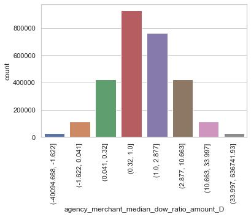

```python
plt.figure(figsize=(6,4))
g = sns.countplot(x="agency_merchant_median_dow_ratio_amount_D", data=df6)
g.set_xticklabels(g.get_xticklabels(), rotation=90)
```

Combine df6 into one data frame df

```python
df['agency_merchant_median_dow_ratio_amount']=df6['agency_merchant_median_dow_ratio_amount']
df['agency_merchant_median_dow_ratio_amount_D']=df6['agency_merchant_median_dow_ratio_amount_D']
```

### 2.7 Feature 7: Merchant popularity: Total transaction

#### Data exploration:

A lot of merchant categories only have one transaction history. However, there are some categories having a lot of transactions. How to make this transaction data meaningful for this feature engineering?

```python
# It still aggregates by merchant agency and merchant category
stat_by_agency = df.groupby(['Agency_Name', 'Merchant_Category']).size()
stat_by_agency = pd.DataFrame(stat_by_agency)
stat_by_agency.columns = ['agency_merchant_total_transaction']
stat_by_agency
```

| Agency_Name | Merchant_Category | agency_merchant_total_transaction |
| --- | --- | --- |
| ARDMORE HIGHER EDUCATION CENTER | BUSINESS SERVICES NOT ELSEWHERE CLASSIFIED | 1 |
|  | CATALOG MERCHANTS | 7 |
|  | COMPUTER NETWORK/INFORMATION SERVICES | 1 |
|  | DRUG STORES AND PHARMACIES | 1 |
|  | GROCERY STORES,AND SUPERMARKETS | 11 |
| ... | ... | ... |
| `DEPARTMENT OF EDUCATION | TELECOMMUNICATION SERVICES | 5 |
|  | TRAVEL AGENCIES | 134 |
|  | TROPICANA RESORT AND CASINO | 1 |
|  | UNITED AIRLINES | 19 |
|  | WYNDHAM HOTELS | 7 |

8427 rows × 1 columns

```python
# add the new feature transaction to the dataset
df7 = pd.merge(df, stat_by_agency, how='left', on=['Agency_Name', 'Merchant_Category'])
df7['agency_merchant_total_transaction'].describe()
```

```
count    442458.000000
mean       1742.530346
std        2137.243288
min           1.000000
25%         149.000000
50%         743.000000
75%        2505.000000
max        8102.000000
Name: agency_merchant_total_transaction, dtype: float64
```

```python
# cut by percentile for plotting
var = 'agency_merchant_total_transaction'
binned_var = var + '_D'
percentile = [0,0.01,0.05,0.2,0.5,0.8,0.95,0.99,1]
df7[binned_var] = pd.qcut(df7[var],percentile,duplicates='drop')
df7[['agency_merchant_total_transaction_D']]
```

|  | agency_merchant_total_transaction_D |
| --- | --- |
| 0 | (743.0, 3311.0] |
| 1 | (96.0, 743.0] |
| 2 | (743.0, 3311.0] |
| 3 | (6709.0, 8102.0] |
| 4 | (743.0, 3311.0] |
| ... | ... |
| 442453 | (13.0, 96.0] |
| 442454 | (96.0, 743.0] |
| 442455 | (96.0, 743.0] |
| 442456 | (96.0, 743.0] |
| 442457 | (96.0, 743.0] |

442458 rows × 1 columns

```
[Text(0, 0, '(0.999, 3.0]'),
```

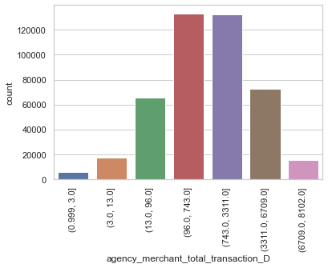

```python
plt.figure(figsize=(6,4))
g = sns.countplot(x="agency_merchant_total_transaction_D", data=df7)
g.set_xticklabels(g.get_xticklabels(), rotation=90)
```

Merge df7 into df

```python
df['agency_merchant_total_transaction']=df7['agency_merchant_total_transaction']
df['agency_merchant_total_transaction_D']=df7['agency_merchant_total_transaction_D']
```

## Feature Engineering-----Cardholder Part

#### Outlook:

- In this part, I will create feature from primarily the side of cardholder.
- The comsumption habit and consumption level of a cardholder is hard to change. They also keep a same frequence and amount on their consumption. It makes sense to compare the spending of a cardholder to another. You cannot claim anomalies just because the spending on cardholder is higher than another.
- So we will aggregate card holder level then build features.
- Common sense tells us the comparison should be at "Cardholder Last Name" and "Cardholder First Initial" level.

### 2.8 Feature 8: The ratio to average amount by cardholder name

```python
# create average spending group by "Cardholder Last Name" and "Cardholder First Initial"
stat_by_cardholder = df.groupby(["Cardholder_Last_Name", "Cardholder_First_Initial" ])['Amount'].mean()
stat_by_cardholder = pd.DataFrame(stat_by_cardholder)
stat_by_cardholder.columns = ['AVG_amount']
stat_by_cardholder.head(15)
```

| Cardholder_Last_Name | Cardholder_First_Initial | AVG_amount |
| --- | --- | --- |
| 15000 | 1 | 4626.460000 |
| 24100 | 2 | 278.409000 |
| 42000 | 4 | 133.998125 |
| 44600 | 4 | 111.990000 |
| 48000 | 4 | 96.774615 |
| 53000 | 5 | 0.040000 |
| 53100 | 5 | 0.000000 |
| 60500 | 6 | 125.050000 |
| 75000 | 7 | 29873.610000 |
| 77000 | 7 | 609039.725000 |
| 81500 | 8 | 171619.610000 |
| 88000 | 8 | 0.000000 |
| 98000 | 9 | 0.000000 |
| AARON | B | 463.333333 |
| ACREE | T | 325.296977 |

The top 13 cardholder's name is wired. But it is a samll part, just ignore here.

```python
# add the new feature average spending to the dataset
df8 = pd.merge(df, stat_by_cardholder, how='left', on=["Cardholder_Last_Name", "Cardholder_First_Initial"])
# Feature 1: ratio of amount spending and avergae spending by merchant category
df8['cardholder_avg_ratio_amount'] = np.where(df8['AVG_amount']==0,0, df8['Amount'] / df8['AVG_amount'])
df8['cardholder_avg_ratio_amount'].describe()
```

```
count    442458.000000
mean          0.999941
std           1.979013
min         -66.279236
25%           0.136551
50%           0.431772
75%           1.174146
max         112.838952
Name: cardholder_avg_ratio_amount, dtype: float64
```

```python
var = 'cardholder_avg_ratio_amount'
binned_var = var + '_D'
percentile = [0,0.01,0.05,0.2,0.5,0.8,0.95,0.99,1]
df8[binned_var] = pd.qcut( df8[var],percentile)
```

plot the feature category graph

```
[Text(0, 0, '(-66.28, -0.65]'),
```

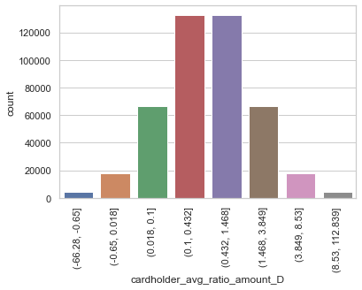

```python
plt.figure(figsize=(6,4))
g = sns.countplot(x="cardholder_avg_ratio_amount_D", data=df8)
g.set_xticklabels(g.get_xticklabels(), rotation=90)
```

```python
# merge df8 to df
df['AVG_amount_CardholderPart'] = df8['AVG_amount']
df['cardholder_avg_ratio_amount']=df8['cardholder_avg_ratio_amount']
df['cardholder_avg_ratio_amount_D']=df8['cardholder_avg_ratio_amount_D']
```

### 2.9 Feature 9: The ratio to median amount by cardholder name

- The only difference is change average to median.

```python
# create median spending group by "Cardholder Last Name" and "Cardholder First Initial"
stat_by_cardholder = df.groupby(["Cardholder_Last_Name", "Cardholder_First_Initial" ])['Amount'].median()
stat_by_cardholder = pd.DataFrame(stat_by_cardholder)
stat_by_cardholder.columns = ['median_amount']
```

```python
# add the new feature median spending to the dataset
df9 = pd.merge(df, stat_by_cardholder, how='left', on=["Cardholder_Last_Name", "Cardholder_First_Initial"])
# Feature 1: ratio of amount spending and median spending by cardholder category
df9['cardholder_median_ratio_amount'] = np.where(df9['median_amount']==0,0, df9['Amount'] / df9['median_amount'])
df9['cardholder_median_ratio_amount'].describe()
```

```
count    4.424580e+05
mean     1.061666e+02
std      4.860020e+04
min     -2.436286e+02
25%      3.824971e-01
50%      1.000000e+00
75%      2.559881e+00
max      2.379823e+07
Name: cardholder_median_ratio_amount, dtype: float64
```

Compared to the std of ratio to average amount 1.979013, this median amount show a huge higher standard deviation 4.860020e+04.

```python
var = 'cardholder_median_ratio_amount'
binned_var = var + '_D'
percentile = [0,0.01,0.05,0.2,0.5,0.8,0.95,0.99,1]
df9[binned_var] = pd.qcut( df9[var],percentile)
```

plot the feature category graph

```
[Text(0, 0, '(-243.63, -1.447]'),
```

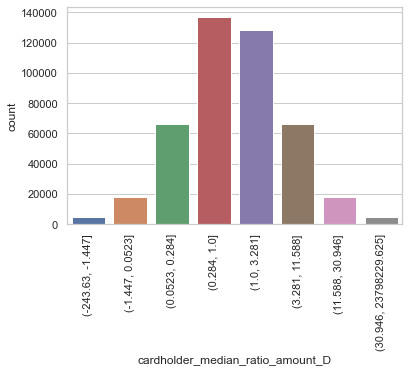

```python
plt.figure(figsize=(6,4))
g = sns.countplot(x="cardholder_median_ratio_amount_D", data=df9)
g.set_xticklabels(g.get_xticklabels(), rotation=90)
```

```python
# merge df9 to df
df['cardholder_median_ratio_amount']=df9['cardholder_median_ratio_amount']
df['cardholder_median_ratio_amount_D']=df9['cardholder_median_ratio_amount_D']
```

### 2.10 Feature 10: The ratio to average amount by cardholder name by month

```python
# create median spending group by "Cardholder Last Name", "Cardholder First Initial" and "month"
stat_by_cardholder = df.groupby(["Cardholder_Last_Name", "Cardholder_First_Initial", "Month"])['Amount'].mean()
stat_by_cardholder = pd.DataFrame(stat_by_cardholder)
stat_by_cardholder.columns = ['AVG_amount']
```

```python
df10 = pd.merge(df, stat_by_cardholder, how='left', on=["Cardholder_Last_Name", "Cardholder_First_Initial","Month"])
# Feature 1: ratio of amount spending and median spending by cardholder category
df10['cardholder_avg_month_ratio_amount'] = np.where(df10['AVG_amount']==0,0, df10['Amount'] / df10['AVG_amount'])
df10['cardholder_avg_month_ratio_amount'].describe()
```

```
count    4.424580e+05
mean     9.969590e-01
std      1.483136e+14
min     -7.151575e+16
25%      1.612844e-01
50%      5.431929e-01
75%      1.307389e+00
max      6.403556e+16
Name: cardholder_avg_month_ratio_amount, dtype: float64
```

```python
var = 'cardholder_avg_month_ratio_amount'
binned_var = var + '_D'
percentile = [0,0.01,0.05,0.2,0.5,0.8,0.95,0.99,1]
df10[binned_var] = pd.qcut( df10[var],percentile)
```

```
[Text(0, 0, '(-7.151575470775992e+16, -0.909]'),
```

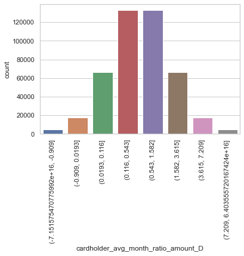

```python
plt.figure(figsize=(6,4))
g = sns.countplot(x="cardholder_avg_month_ratio_amount_D", data=df10)
g.set_xticklabels(g.get_xticklabels(), rotation=90)
```

[output not shown]

```python
# merge df10 to df
df['AVG_amount_CardholderPart_month'] = df10['AVG_amount']
df['cardholder_avg_month_ratio_amount']=df10['cardholder_avg_month_ratio_amount']
df['cardholder_avg_month_ratio_amount_D']=df10['cardholder_avg_month_ratio_amount_D']
```

### 2.11 Feature 11: The ratio to median amount by cardholder name by month

- Notice the only different to above feature is median amount

```python
# create median spending group by "Cardholder Last Name", "Cardholder First Initial" and "month"
stat_by_cardholder = df.groupby(["Cardholder_Last_Name", "Cardholder_First_Initial", "Month"])['Amount'].median()
stat_by_cardholder = pd.DataFrame(stat_by_cardholder)
stat_by_cardholder.columns = ['median_amount']
```

```python
df11 = pd.merge(df, stat_by_cardholder, how='left', on=["Cardholder_Last_Name", "Cardholder_First_Initial","Month"])
# Feature 1: ratio of amount spending and median spending by cardholder category
df11['cardholder_median_month_ratio_amount'] = np.where(df11['median_amount']==0,0, df11['Amount'] / df11['median_amount'])
df11['cardholder_median_month_ratio_amount'].describe()
```

```
count    442458.000000
mean          2.614972
std          85.095847
min      -49090.000000
25%           0.419041
50%           1.000000
75%           2.189440
max        6000.000000
Name: cardholder_median_month_ratio_amount, dtype: float64
```

```python
var = 'cardholder_median_month_ratio_amount'
binned_var = var + '_D'
percentile = [0,0.01,0.05,0.2,0.5,0.8,0.95,0.99,1]
df11[binned_var] = pd.qcut( df11[var],percentile)
```

```
[Text(0, 0, '(-49090.001, -1.454]'),
```

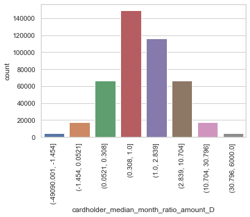

```python
plt.figure(figsize=(6,4))
g = sns.countplot(x="cardholder_median_month_ratio_amount_D", data=df11)
g.set_xticklabels(g.get_xticklabels(), rotation=90)
```

```python
# merge df11 to df
df['cardholder_median_month_ratio_amount']=df11['cardholder_median_month_ratio_amount']
df['cardholder_median_month_ratio_amount_D']=df11['cardholder_median_month_ratio_amount_D']
```

## Notice:

- The average and median amount of spending for cardholder in week and day of week are also exploratory. But I will temporarily leave the combination of these 4 features since their process is very similar to above feature. In the following two feature I will talk about number of transaction since I talk less in the merchant part.

### Creating data for transaction ratio

The amount of transaction for each cardholder within a year:

```python
# count total transaction number by cardholder name
stat_by_cardholder = df.groupby(["Cardholder_Last_Name", "Cardholder_First_Initial"]).size()
stat_by_cardholder = pd.DataFrame(stat_by_cardholder)
stat_by_cardholder.columns = ['transaction_y']

# add the new feature transaction size to the dataset
df_1 = pd.merge(df, stat_by_cardholder, how='left', on=["Cardholder_Last_Name", "Cardholder_First_Initial"])
df_1['cardholder_total_transaction'] = df_1['transaction_y']
df_1['cardholder_total_transaction'].describe()
```

```
count    442458.000000
mean        783.930714
std        1834.541343
min           1.000000
25%          90.000000
50%         200.000000
75%         506.000000
max       10137.000000
Name: cardholder_total_transaction, dtype: float64
```

The amount of transaction for each cardholder for each month:

```python
# count transaction number by cardholder name for each month
stat_by_cardholder = df.groupby(["Cardholder_Last_Name", "Cardholder_First_Initial","Month"]).size()
stat_by_cardholder = pd.DataFrame(stat_by_cardholder)
stat_by_cardholder.columns = ['transaction_m']

# add the new feature transaction size to the dataset df_1
df_2 = pd.merge(df_1, stat_by_cardholder, how='left', on=["Cardholder_Last_Name", "Cardholder_First_Initial","Month"])
df_2['cardholder_month_transaction'] = df_2['transaction_m']
df_2['cardholder_month_transaction'].describe()
```

```
count    442458.000000
mean         72.771418
std         165.067287
min           1.000000
25%          10.000000
50%          21.000000
75%          51.000000
max        1330.000000
Name: cardholder_month_transaction, dtype: float64
```

The amount of transaction for each cardholder for each week:

```python
# count transaction number by cardholder name for each week
stat_by_cardholder = df.groupby(["Cardholder_Last_Name", "Cardholder_First_Initial", 'Month',"Week_Number"]).size()
stat_by_cardholder = pd.DataFrame(stat_by_cardholder)
stat_by_cardholder.columns = ['transaction_w']

# add the new feature transaction size to the dataset df_2
# df_3 combined all three number above
df_3 = pd.merge(df_2, stat_by_cardholder, how='left', on=["Cardholder_Last_Name", "Cardholder_First_Initial","Month", 'Week_Number'])
df_3['cardholder_week_transaction'] = df_3['transaction_w']
df_3['cardholder_week_transaction'].describe()
```

```
count    442458.000000
mean         18.555099
std          40.575818
min           1.000000
25%           3.000000
50%           6.000000
75%          15.000000
max         473.000000
Name: cardholder_week_transaction, dtype: float64
```

### 2.12 Feature 12: Transaction ratio by cardholder for a course of month in the year

- It is not make sense to compared the amount of transaction between different cardholders. As I talk befor, differenent pepole have different consumption habit. So the ratio is a good unit to see.
- I make a feature to show the ratio of transaction by cardholder in a time period of month in the year to see cardholder's transaction behavior.
- It is the division of cardholder_month_transaction and cardholder_total_transaction

The ratio of amount of transaction by month is diviation of above two value:

```python
#create a new taget value: month transaction/total transaction
df_3['cardholder_m/y_ratio_transaction'] = np.where(df_3['cardholder_total_transaction']==0,0, df_3['cardholder_month_transaction'] / df_2['cardholder_total_transaction'])
df_3['cardholder_m/y_ratio_transaction'].describe()
```

```
count    442458.000000
mean          0.125497
std           0.101489
min           0.001862
25%           0.076336
50%           0.097826
75%           0.135314
max           1.000000
Name: cardholder_m/y_ratio_transaction, dtype: float64
```

```python
# cut by percentile for plotting and plot the classification graph
var = 'cardholder_m/y_ratio_transaction'
binned_var = var + '_D'
percentile = [0,0.01,0.05,0.2,0.5,0.8,0.95,0.99,1]
df_3[binned_var] = pd.qcut( df_3[var],percentile)
```

```
[Text(0, 0, '(0.0008600000000000001, 0.0273]'),
```

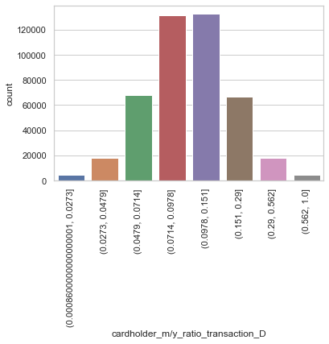

```python
# plot the graph
plt.figure(figsize=(6,4))
g = sns.countplot(x="cardholder_m/y_ratio_transaction_D", data=df_3)
g.set_xticklabels(g.get_xticklabels(), rotation=90)
```

```python
# merge df_3 to df
df['cardholder_m/y_ratio_transaction']=df_3['cardholder_m/y_ratio_transaction']
df['cardholder_m/y_ratio_transaction_D']=df_3['cardholder_m/y_ratio_transaction_D']
```

```python
#create a new taget value: week transaction/month transaction
df_3['cardholder_w/m_ratio_transaction'] = np.where(df_3['cardholder_month_transaction']==0,0, df_3['cardholder_week_transaction'] / df_2['cardholder_total_transaction'])
df_3['cardholder_w/m_ratio_transaction'].describe()
```

```
count    442458.000000
mean          0.045813
std           0.063253
min           0.000099
25%           0.018683
50%           0.028814
75%           0.048780
max           1.000000
Name: cardholder_w/m_ratio_transaction, dtype: float64
```

```python
# cut by percentile for plotting and plot the classification graph
var = 'cardholder_w/m_ratio_transaction'
binned_var = var + '_D'
percentile = [0,0.01,0.05,0.2,0.5,0.8,0.95,0.99,1]
df_3[binned_var] = pd.qcut( df_3[var],percentile)
```

```
[Text(0, 0, '(-0.0009014, 0.00459]'),
```

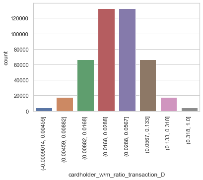

```python
# plot the graph
plt.figure(figsize=(6,4))
g = sns.countplot(x="cardholder_w/m_ratio_transaction_D", data=df_3)
g.set_xticklabels(g.get_xticklabels(), rotation=90)
```

```python
# merge df_3 to df
df['cardholder_w/m_ratio_transaction']=df_3['cardholder_w/m_ratio_transaction']
df['cardholder_w/m_ratio_transaction_D']=df_3['cardholder_w/m_ratio_transaction_D']
```

## Section 5 Feature Engineering-----Merchant and Cardholder Part

- We have talked about the amount of spending and transaction form two sides seperately: merchant and cardholder side. It is obvious that we can combine them together and have a closer look at the transaction behavior of carholder on different merchant category. It is content rich feature worth usng in this feature engineering.
- Actually there are a lot combination under this one: adding time period like week, day of week, month for both amount of spending or transaction. I only show the most common one.
- It is the combination of "Cardholder_Last_Name", "Cardholder_First_Initial", 'Agency_Name', 'Merchant_Category'

### 2.14 Feature 14: The ratio to average amount

```python
# create average spending group by "Cardholder Last Name", "Cardholder First Initial" and 'Agency_Name', 'Merchant_Category'
stat_by_cardholder = df.groupby(["Cardholder_Last_Name", "Cardholder_First_Initial", 'Agency_Name', 'Merchant_Category'])['Amount'].mean()
stat_by_cardholder = pd.DataFrame(stat_by_cardholder)
stat_by_cardholder.columns = ['AVG_amount']
```

```python
# add the new feature average spending to the dataset
df14 = pd.merge(df, stat_by_cardholder, how='left', on=["Cardholder_Last_Name", "Cardholder_First_Initial",'Agency_Name', 'Merchant_Category'])
# Feature 1: ratio of amount spending and avergae spending by merchant category
df14['cardholder_agency_merchant_avg_ratio_amount'] = np.where(df14['AVG_amount']==0,0, df14['Amount'] / df14['AVG_amount'])
df14['cardholder_agency_merchant_avg_ratio_amount'].describe()
```

```
count    4.424580e+05
mean     7.504713e-01
std      4.286705e+15
min     -7.901622e+17
25%      3.534415e-01
50%      8.380322e-01
75%      1.200000e+00
max      7.901622e+17
Name: cardholder_agency_merchant_avg_ratio_amount, dtype: float64
```

```python
# cut by percentile for plotting
var = 'cardholder_agency_merchant_avg_ratio_amount'
binned_var = var + '_D'
percentile = [0,0.01,0.05,0.2,0.5,0.8,0.95,0.99,1]
df14[binned_var] = pd.qcut(df14[var],percentile)
```

```
[Text(0, 0, '(-7.901621841216878e+17, -0.937]'),
```

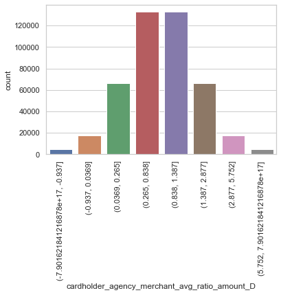

```python
import matplotlib.pyplot as plt
plt.figure(figsize=(6,4))
g = sns.countplot(x="cardholder_agency_merchant_avg_ratio_amount_D", data=df14)
g.set_xticklabels(g.get_xticklabels(), rotation=90)
```

```python
# merge df14 to df
df['AVG_amount_BothPart'] = df14['AVG_amount']
df['cardholder_agency_merchant_avg_ratio_amount']=df14['cardholder_agency_merchant_avg_ratio_amount']
df['cardholder_agency_merchant_avg_ratio_amount_D']=df14['cardholder_agency_merchant_avg_ratio_amount_D']
```

### 2.15 Feature 15: The ratio to median amount

```python
# create average spending group by "Cardholder Last Name", "Cardholder First Initial" and 'Agency_Name', 'Merchant_Category'
stat_by_cardholder = df.groupby(["Cardholder_Last_Name", "Cardholder_First_Initial", 'Agency_Name', 'Merchant_Category'])['Amount'].median()
stat_by_cardholder = pd.DataFrame(stat_by_cardholder)
stat_by_cardholder.columns = ['median_amount']
```

```python
df15 = pd.merge(df, stat_by_cardholder, how='left', on=["Cardholder_Last_Name", "Cardholder_First_Initial",'Agency_Name', 'Merchant_Category'])
# Feature 1: ratio of amount spending and avergae spending by merchant category
df15['cardholder_agency_merchant_median_ratio_amount'] = np.where(df15['median_amount']==0,0, df15['Amount'] / df15['median_amount'])
df15['cardholder_agency_merchant_median_ratio_amount'].describe()
```

```
count    4.424580e+05
mean     1.050664e+02
std      4.860020e+04
min     -8.195918e+02
25%      6.256754e-01
50%      1.000000e+00
75%      1.497567e+00
max      2.379823e+07
Name: cardholder_agency_merchant_median_ratio_amount, dtype: float64
```

```python
# cut by percentile for plotting
var = 'cardholder_agency_merchant_median_ratio_amount'
binned_var = var + '_D'
percentile = [0,0.01,0.05,0.2,0.5,0.8,0.95,0.99,1]
df15[binned_var] = pd.qcut(df15[var],percentile)
```

```
[Text(0, 0, '(-819.593, -1.077]'),
```

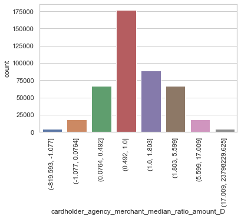

```python
plt.figure(figsize=(6,4))
g = sns.countplot(x="cardholder_agency_merchant_median_ratio_amount_D", data=df15)
g.set_xticklabels(g.get_xticklabels(), rotation=90)
```

```python
# merge df15 to df
df['cardholder_agency_merchant_median_ratio_amount']=df15['cardholder_agency_merchant_median_ratio_amount']
df['cardholder_agency_merchant_median_ratio_amount_D']=df15['cardholder_agency_merchant_median_ratio_amount_D']
```

### Future Outlook

Actually, there are much more combination for this feature enginnering, which is meanfuling to find anamolies

- For Merchant part, I can do more on amount of transaction, which I did on cardholder part
- For Cardholder part, I can do more on amount of spending, aggregating by week, week of day, which I did on merchant part
- For the last section, Merchant and Cardholder part, I can do every combination I have done in the last two section.

To better find anamolies, this purchase credit card transactions data can provide more information like prcise address of purchase address, currency and so on

## Feature Engineering--Improved/revised features

- Lead: I may want to check the outliers when I use average, since the outliers will impact the average a lot. In this time, I am not only focus on which combination of state and DRG is abnormal as whole, but try to fiture out which data is outlier within these combination.
- Analysis: A lot of z-score are really high. It proved that there are many outliers impacting the average. Just add feature of average payment is not sufficient, the z-score analysis is also necessary.

### 2.16 Feature 16: z-score of Merchant Part

```python
# create standard deviation spending group by agency and merchant category
stat_by_agency = df.groupby(['Agency_Name', 'Merchant_Category'])['Amount'].std()
stat_by_agency = pd.DataFrame(stat_by_agency)
stat_by_agency.columns = ['Std']
stat_by_agency
```

| Agency_Name | Merchant_Category | Std |
| --- | --- | --- |
| ARDMORE HIGHER EDUCATION CENTER | BUSINESS SERVICES NOT ELSEWHERE CLASSIFIED | NaN |
|  | CATALOG MERCHANTS | 501.068650 |
|  | COMPUTER NETWORK/INFORMATION SERVICES | NaN |
|  | DRUG STORES AND PHARMACIES | NaN |
|  | GROCERY STORES,AND SUPERMARKETS | 51.500693 |
| ... | ... | ... |
| `DEPARTMENT OF EDUCATION | TELECOMMUNICATION SERVICES | 56.843289 |
|  | TRAVEL AGENCIES | 6.085465 |
|  | TROPICANA RESORT AND CASINO | NaN |
|  | UNITED AIRLINES | 553.680509 |
|  | WYNDHAM HOTELS | 203.470948 |

8427 rows × 1 columns

```python
# add standard deviation to the dataset, and get the z-score.
# If the standard deviation is NaN, set as 0 z-score
df16 = pd.merge(df, stat_by_agency, how='left', on=['Agency_Name', 'Merchant_Category'])
df16['Std_agency_merchant_avg'] = np.where(df16['Std']== 'NaN', 0, df16['Std'])
# Feature 1: ratio of amount spending and avergae spending by merchant category
df16['Zscore_agency_merchant_avg_amount'] = np.where(df16['Std_agency_merchant_avg']==0,0, (df16['Amount']- df16['AVG_amount_MerchantPart'])/df16['Std_agency_merchant_avg'])
df16['Zscore_agency_merchant_avg_amount'].describe()
```

```
count    4.406080e+05
mean     6.993333e-17
std      9.906372e-01
min     -2.911219e+01
25%     -4.096682e-01
50%     -2.143129e-01
75%      5.943620e-02
max      3.847653e+01
Name: Zscore_agency_merchant_avg_amount, dtype: float64
```

```
[(-10.0, 10.0)]
```

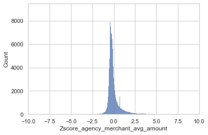

```python
sns.histplot(df16['Zscore_agency_merchant_avg_amount']).set(xlim=(-10,10))
```

- I can see the average payment z-score graph is skewed to right. The outlier always in a way of high value. The hospital abuse activity always happens in a way of high average total payment. I cannot see any discharge related conclusion in this feature.

```python
# cut by percentile for plotting
var = 'Zscore_agency_merchant_avg_amount'
binned_var = var + '_D'
percentile = [0,0.01,0.05,0.2,0.5,0.8,0.95,0.99,1]
df16[binned_var] = pd.qcut(df16[var],percentile)
```

```
[Text(0, 0, '(-29.113, -1.278]'),
```

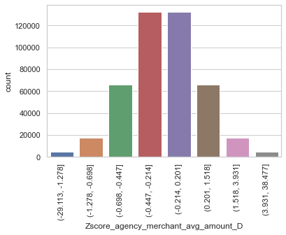

```python
plt.figure(figsize=(6,4))
g = sns.countplot(x="Zscore_agency_merchant_avg_amount_D", data=df16)
g.set_xticklabels(g.get_xticklabels(), rotation=90)
```

```python
df["Zscore_agency_merchant_avg_amount"] = df16['Zscore_agency_merchant_avg_amount']
df["Zscore_agency_merchant_avg_amount_D"] = df16['Zscore_agency_merchant_avg_amount_D']
```

### 2.17 Feature 17: z-score of Merchant Part by month

```python
# create standard deviation spending group by agency and merchant category every month
stat_by_agency = df.groupby(['Agency_Name', 'Merchant_Category','Month'])['Amount'].std()
stat_by_agency = pd.DataFrame(stat_by_agency)
stat_by_agency.columns = ['Std']
stat_by_agency
```

| Agency_Name | Merchant_Category | Month | Std |
| --- | --- | --- | --- |
| ARDMORE HIGHER EDUCATION CENTER | BUSINESS SERVICES NOT ELSEWHERE CLASSIFIED | 11 | NaN |
|  | CATALOG MERCHANTS | 7 | 44.307311 |
|  |  | 8 | NaN |
|  |  | 9 | NaN |
|  |  | 10 | NaN |
| ... | ... | ... | ... |
| `DEPARTMENT OF EDUCATION | UNITED AIRLINES | 9 | 861.080396 |
|  |  | 10 | 0.000000 |
|  |  | 12 | 36.411079 |
|  | WYNDHAM HOTELS | 1 | 431.306852 |
|  |  | 12 | 97.483620 |

39888 rows × 1 columns

```python
# add standard deviation to the dataset, and get the z-score.
# If the standard deviation is NaN, set as 0 z-score
df17 = pd.merge(df, stat_by_agency, how='left', on=['Agency_Name', 'Merchant_Category', 'Month'])
df17['Std_agency_merchant_month_avg'] = np.where(df17['Std']== 'NaN', 0, df17['Std'])
# Feature 1: ratio of amount spending and avergae spending by merchant category
df17['Zscore_agency_merchant_month_avg_amount'] = np.where(df17['Std_agency_merchant_month_avg']==0,0, (df17['Amount']- df17['AVG_amount_MerchantPart_month'])/df17['Std_agency_merchant_month_avg'])
df17['Zscore_agency_merchant_month_avg_amount'].describe()
```

```
count    4.276530e+05
mean    -1.670113e-17
std      9.628929e-01
min     -1.469802e+01
25%     -4.625484e-01
50%     -2.425669e-01
75%      1.415763e-01
max      2.132620e+01
Name: Zscore_agency_merchant_month_avg_amount, dtype: float64
```

```
[(-7.0, 7.0)]
```

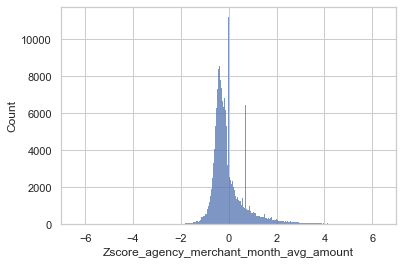

```python
sns.histplot(df17['Zscore_agency_merchant_month_avg_amount']).set(xlim=(-7,7))
```

```python
# cut by percentile for plotting
var = 'Zscore_agency_merchant_month_avg_amount'
binned_var = var + '_D'
percentile = [0,0.01,0.05,0.2,0.5,0.8,0.95,0.99,1]
df17[binned_var] = pd.qcut(df17[var],percentile)
```

```
[Text(0, 0, '(-14.699, -1.381]'),
```

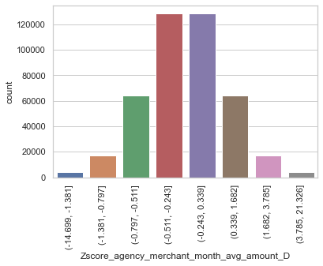

```python
plt.figure(figsize=(6,4))
g = sns.countplot(x="Zscore_agency_merchant_month_avg_amount_D", data=df17)
g.set_xticklabels(g.get_xticklabels(), rotation=90)
```

```python
df["Zscore_agency_merchant_month_avg_amount"] = df17['Zscore_agency_merchant_month_avg_amount']
df["Zscore_agency_merchant_month_avg_amount_D"] = df17['Zscore_agency_merchant_month_avg_amount_D']
```

### 2.18 Feature 18: z-score of Cardholder Part

```python
# create standard deviation group by "Cardholder Last Name" and "Cardholder First Initial"
stat_by_cardholder = df.groupby(["Cardholder_Last_Name", "Cardholder_First_Initial"])['Amount'].std()
stat_by_cardholder = pd.DataFrame(stat_by_cardholder)
stat_by_cardholder.columns = ['Std']
stat_by_cardholder.head()
```

| Cardholder_Last_Name | Cardholder_First_Initial | Std |
| --- | --- | --- |
| 15000 | 1 | NaN |
| 24100 | 2 | 582.580400 |
| 42000 | 4 | 158.922422 |
| 44600 | 4 | NaN |
| 48000 | 4 | 162.240903 |

```python
# add standard deviation to the dataset, and get the z-score.
# If the standard deviation is NaN, set as 0 z-score
df18 = pd.merge(df, stat_by_cardholder, how='left', on=["Cardholder_Last_Name", "Cardholder_First_Initial"])
df18['Std_cardholder_avg'] = np.where(df18['Std']== 'NaN', 0, df18['Std'])
# Feature 1: ratio of amount spending and avergae spending by merchant category
df18['Zscore_cardholder_avg_amount'] = np.where(df18['Std_cardholder_avg']==0,0, (df18['Amount']- df18['AVG_amount_CardholderPart'])/df18['Std_cardholder_avg'])
df18['Zscore_cardholder_avg_amount'].describe()
```

```
count    4.422810e+05
mean     1.323607e-15
std      9.942450e-01
min     -1.279051e+01
25%     -4.753644e-01
50%     -2.876038e-01
75%      1.057141e-01
max      3.881973e+01
Name: Zscore_cardholder_avg_amount, dtype: float64
```

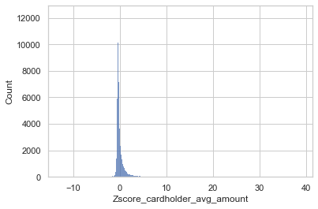

```python
sns.histplot(df18['Zscore_cardholder_avg_amount'])
```

```python
# cut by percentile for plotting
var = 'Zscore_cardholder_avg_amount'
binned_var = var + '_D'
percentile = [0,0.01,0.05,0.2,0.5,0.8,0.95,0.99,1]
df18[binned_var] = pd.qcut(df18[var],percentile)
```

```
[Text(0, 0, '(-12.792, -1.128]'),
```

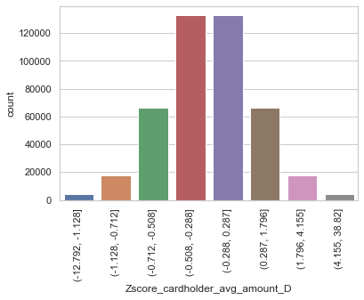

```python
plt.figure(figsize=(6,4))
g = sns.countplot(x="Zscore_cardholder_avg_amount_D", data=df18)
g.set_xticklabels(g.get_xticklabels(), rotation=90)
```

```python
df["Zscore_cardholder_avg_amount"] = df18['Zscore_cardholder_avg_amount']
df["Zscore_cardholder_avg_amount_D"] = df18['Zscore_cardholder_avg_amount_D']
```

### 2.19 Feature 19: z-score of Cardholder Part by month

```python
# create standard deviation group by "Cardholder Last Name" , "Cardholder First Initial" and "Month"
stat_by_cardholder = df.groupby(["Cardholder_Last_Name", "Cardholder_First_Initial",'Month'])['Amount'].std()
stat_by_cardholder = pd.DataFrame(stat_by_cardholder)
stat_by_cardholder.columns = ['Std']
stat_by_cardholder.head()
```

| Cardholder_Last_Name | Cardholder_First_Initial | Month | Std |
| --- | --- | --- | --- |
| 15000 | 1 | 4 | NaN |
| 24100 | 2 | 1 | NaN |
|  |  | 3 | 24.960869 |
|  |  | 7 | 1258.077314 |
|  |  | 8 | 509.095669 |

```python
# add standard deviation to the dataset, and get the z-score.
# If the standard deviation is NaN, set as 0 z-score
df19 = pd.merge(df, stat_by_cardholder, how='left', on=["Cardholder_Last_Name", "Cardholder_First_Initial",'Month'])
df19['Std_cardholder_month_avg'] = np.where(df19['Std']== 'NaN', 0, df18['Std'])
# Feature 1: ratio of amount spending and avergae spending by merchant category
df19['Zscore_cardholder_month_avg_amount'] = np.where(df19['Std_cardholder_month_avg']==0,0, (df19['Amount']- df19['AVG_amount_CardholderPart_month'])/df19['Std_cardholder_month_avg'])
df19['Zscore_cardholder_month_avg_amount'].describe()
```

```
count    4.422810e+05
mean    -2.856945e-18
std      9.426334e-01
min     -1.266240e+01
25%     -4.527729e-01
50%     -1.780183e-01
75%      1.366229e-01
max      3.877683e+01
Name: Zscore_cardholder_month_avg_amount, dtype: float64
```

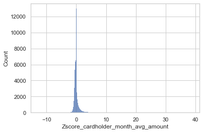

```python
sns.histplot(df19['Zscore_cardholder_month_avg_amount'])
```

```python
# cut by percentile for plotting
var = 'Zscore_cardholder_month_avg_amount'
binned_var = var + '_D'
percentile = [0,0.01,0.05,0.2,0.5,0.8,0.95,0.99,1]
df19[binned_var] = pd.qcut(df19[var],percentile)
```

```
[Text(0, 0, '(-12.663, -1.415]'),
```

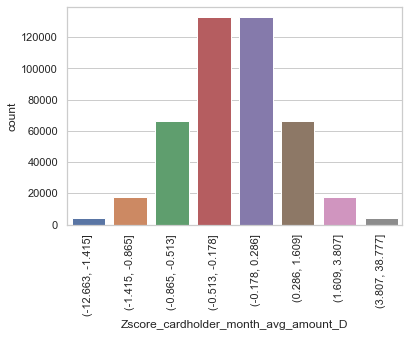

```python
plt.figure(figsize=(6,4))
g = sns.countplot(x="Zscore_cardholder_month_avg_amount_D", data=df19)
g.set_xticklabels(g.get_xticklabels(), rotation=90)
```

```python
df["Zscore_cardholder_month_avg_amount"] = df19['Zscore_cardholder_month_avg_amount']
df["Zscore_cardholder_month_avg_amount_D"] = df19['Zscore_cardholder_month_avg_amount_D']
```

### 2.20 Feature 20: z-score of Cardholder Part by both Merchant and Cardholder Part

```python
# create standard deviation spending group by "Cardholder Last Name", "Cardholder First Initial" and 'Agency_Name', 'Merchant_Category'
stat_by_cardholder = df.groupby(["Cardholder_Last_Name", "Cardholder_First_Initial", 'Agency_Name', 'Merchant_Category'])['Amount'].std()
stat_by_cardholder = pd.DataFrame(stat_by_cardholder)
stat_by_cardholder.columns = ['Std']
```

```python
# add standard deviation to the dataset, and get the z-score.
# If the standard deviation is NaN, set as 0 z-score
df20 = pd.merge(df, stat_by_cardholder, how='left', on=["Cardholder_Last_Name", "Cardholder_First_Initial", 'Agency_Name', 'Merchant_Category'])
df20['Std_cardholder_agency_merchant_avg'] = np.where(df20['Std']== 'NaN', 0, df20['Std'])
# Feature 1: ratio of amount spending and avergae spending by merchant category
df20['Zscore_cardholder_agency_merchant_avg_amount'] = np.where(df20['Std_cardholder_agency_merchant_avg']==0,0, (df20['Amount']- df20['AVG_amount_BothPart'])/df20['Std_cardholder_agency_merchant_avg'])
df20['Zscore_cardholder_agency_merchant_avg_amount'].describe()
```

```
count    4.129430e+05
mean    -5.976559e-16
std      9.397571e-01
min     -2.931007e+01
25%     -5.534164e-01
50%     -2.080032e-01
75%      3.686162e-01
max      2.189621e+01
Name: Zscore_cardholder_agency_merchant_avg_amount, dtype: float64
```

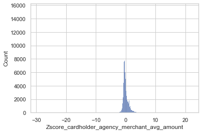

```python
sns.histplot(df20['Zscore_cardholder_agency_merchant_avg_amount'])
```

```python
# cut by percentile for plotting
var = 'Zscore_cardholder_agency_merchant_avg_amount'
binned_var = var + '_D'
percentile = [0,0.01,0.05,0.2,0.5,0.8,0.95,0.99,1]
df20[binned_var] = pd.qcut(df20[var],percentile)
```

```
[Text(0, 0, '(-29.311, -1.631]'),
```

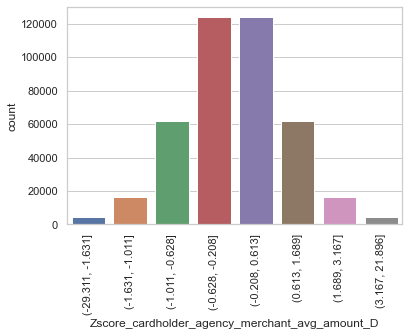

```python
plt.figure(figsize=(6,4))
g = sns.countplot(x="Zscore_cardholder_agency_merchant_avg_amount_D", data=df20)
g.set_xticklabels(g.get_xticklabels(), rotation=90)
```

```python
df["Zscore_cardholder_agency_merchant_avg_amount"] = df20['Zscore_cardholder_agency_merchant_avg_amount']
df["Zscore_cardholder_agency_merchant_avg_amount_D"] = df20['Zscore_cardholder_agency_merchant_avg_amount_D']
```

## Section 3 KNNs

- Merge the features into one data frame so I can do modeling
- Choose 18 feature, do not choose Feature 5: The ratio to average amount by day of week and Feature 6: The ratio to median amount by day of week. The data is meaningless since it has high standard deviation.

```python
data = df[['agency_merchant_avg_ratio_amount','agency_merchant_avg_median_amount','agency_merchant_avg_month_ratio_amount','agency_merchant_median_month_ratio_amount','agency_merchant_total_transaction',
           'cardholder_avg_ratio_amount','cardholder_median_ratio_amount','cardholder_avg_month_ratio_amount','cardholder_median_month_ratio_amount','cardholder_m/y_ratio_transaction','cardholder_w/m_ratio_transaction',
          'cardholder_agency_merchant_avg_ratio_amount','cardholder_agency_merchant_median_ratio_amount',
           'Zscore_agency_merchant_avg_amount', 'Zscore_agency_merchant_month_avg_amount', 'Zscore_cardholder_avg_amount','Zscore_cardholder_month_avg_amount','Zscore_cardholder_agency_merchant_avg_amount']]
```

```python
data.describe()
```

|  | agency_merchant_avg_ratio_amount | agency_merchant_avg_median_amount | agency_merchant_avg_month_ratio_amount | agency_merchant_median_month_ratio_amount | agency_merchant_total_transaction | cardholder_avg_ratio_amount | cardholder_median_ratio_amount | cardholder_avg_month_ratio_amount | cardholder_median_month_ratio_amount | cardholder_m/y_ratio_transaction | cardholder_w/m_ratio_transaction | cardholder_agency_merchant_avg_ratio_amount | cardholder_agency_merchant_median_ratio_amount | Zscore_agency_merchant_avg_amount | Zscore_agency_merchant_month_avg_amount | Zscore_cardholder_avg_amount | Zscore_cardholder_month_avg_amount | Zscore_cardholder_agency_merchant_avg_amount |
| --- | --- | --- | --- | --- | --- | --- | --- | --- | --- | --- | --- | --- | --- | --- | --- | --- | --- | --- |
| count | 442458.000000 | 442458.000000 | 4.424580e+05 | 4.424580e+05 | 442458.000000 | 442458.000000 | 4.424580e+05 | 4.424580e+05 | 442458.000000 | 442458.000000 | 442458.000000 | 4.424580e+05 | 4.424580e+05 | 4.406080e+05 | 4.276530e+05 | 4.422810e+05 | 4.422810e+05 | 4.129430e+05 |
| mean | 0.999724 | 4.952685 | 9.991488e-01 | 9.991488e-01 | 1742.530346 | 0.999941 | 1.061666e+02 | 9.969590e-01 | 2.614972 | 0.125497 | 0.045813 | 7.504713e-01 | 1.050664e+02 | 6.993333e-17 | -1.670113e-17 | 1.323607e-15 | -2.856945e-18 | -5.976559e-16 |
| std | 7.225363 | 1078.581350 | 5.961952e+13 | 5.961952e+13 | 2137.243288 | 1.979013 | 4.860020e+04 | 1.483136e+14 | 85.095847 | 0.101489 | 0.063253 | 4.286705e+15 | 4.860020e+04 | 9.906372e-01 | 9.628929e-01 | 9.942450e-01 | 9.426334e-01 | 9.397571e-01 |
| min | -2735.680000 | -1003.176471 | -2.447706e+16 | -2.447706e+16 | 1.000000 | -66.279236 | -2.436286e+02 | -7.151575e+16 | -49090.000000 | 0.001862 | 0.000099 | -7.901622e+17 | -8.195918e+02 | -2.911219e+01 | -1.469802e+01 | -1.279051e+01 | -1.266240e+01 | -2.931007e+01 |
| 25% | 0.177145 | 0.466090 | 2.017647e-01 | 2.017647e-01 | 149.000000 | 0.136551 | 3.824971e-01 | 1.612844e-01 | 0.419041 | 0.076336 | 0.018683 | 3.534415e-01 | 6.256754e-01 | -4.096682e-01 | -4.625484e-01 | -4.753644e-01 | -4.527729e-01 | -5.534164e-01 |
| 50% | 0.515301 | 1.000000 | 5.984763e-01 | 5.984763e-01 | 743.000000 | 0.431772 | 1.000000e+00 | 5.431929e-01 | 1.000000 | 0.097826 | 0.028814 | 8.380322e-01 | 1.000000e+00 | -2.143129e-01 | -2.425669e-01 | -2.876038e-01 | -1.780183e-01 | -2.080032e-01 |
| 75% | 1.102916 | 2.121102 | 1.125213e+00 | 1.125213e+00 | 2505.000000 | 1.174146 | 2.559881e+00 | 1.307389e+00 | 2.189440 | 0.135314 | 0.048780 | 1.200000e+00 | 1.497567e+00 | 5.943620e-02 | 1.415763e-01 | 1.057141e-01 | 1.366229e-01 | 3.686162e-01 |
| max | 2735.680000 | 528116.052705 | 3.059633e+16 | 3.059633e+16 | 8102.000000 | 112.838952 | 2.379823e+07 | 6.403556e+16 | 6000.000000 | 1.000000 | 1.000000 | 7.901622e+17 | 2.379823e+07 | 3.847653e+01 | 2.132620e+01 | 3.881973e+01 | 3.877683e+01 | 2.189621e+01 |

Replace NA by 0

- Business intuition: the person spends on that month, but not spend on that week. NA means 0 spending, also 0 ratio.

```python
data = data.fillna(0)
```

```python
#pip install pyod
```

```python
data = data.sample(frac=0.3, random_state=1)
```

```python
data.describe()
```

|  | agency_merchant_avg_ratio_amount | agency_merchant_avg_median_amount | agency_merchant_avg_month_ratio_amount | agency_merchant_median_month_ratio_amount | agency_merchant_total_transaction | cardholder_avg_ratio_amount | cardholder_median_ratio_amount | cardholder_avg_month_ratio_amount | cardholder_median_month_ratio_amount | cardholder_m/y_ratio_transaction | cardholder_w/m_ratio_transaction | cardholder_agency_merchant_avg_ratio_amount | cardholder_agency_merchant_median_ratio_amount | Zscore_agency_merchant_avg_amount | Zscore_agency_merchant_month_avg_amount | Zscore_cardholder_avg_amount | Zscore_cardholder_month_avg_amount | Zscore_cardholder_agency_merchant_avg_amount |
| --- | --- | --- | --- | --- | --- | --- | --- | --- | --- | --- | --- | --- | --- | --- | --- | --- | --- | --- |
| count | 132737.000000 | 132737.000000 | 1.327370e+05 | 1.327370e+05 | 132737.000000 | 132737.000000 | 1.327370e+05 | 1.327370e+05 | 132737.000000 | 132737.000000 | 132737.000000 | 1.327370e+05 | 1.327370e+05 | 132737.000000 | 132737.000000 | 132737.000000 | 132737.000000 | 132737.000000 |
| mean | 0.993102 | 6.634550 | 7.745710e-01 | 7.745710e-01 | 1753.257020 | 0.999736 | 1.822380e+02 | -1.189766e+11 | 2.634436 | 0.125189 | 0.045707 | -8.763418e+12 | 1.811874e+02 | 0.000866 | 0.000260 | -0.001387 | -0.000146 | -0.000215 |
| std | 3.537734 | 1449.592619 | 1.088503e+14 | 1.088503e+14 | 2145.281504 | 2.055312 | 6.532037e+04 | 3.999039e+13 | 69.848506 | 0.100795 | 0.062421 | 3.400193e+15 | 6.532038e+04 | 0.996292 | 0.943521 | 0.999022 | 0.948441 | 0.916608 |
| min | -911.893333 | -308.457711 | -2.447706e+16 | -2.447706e+16 | 1.000000 | -59.884434 | -2.007657e+02 | -1.451349e+16 | -22828.000000 | 0.001862 | 0.000197 | -4.388814e+17 | -8.195918e+02 | -11.107257 | -9.172027 | -12.790507 | -12.662404 | -11.175466 |
| 25% | 0.178254 | 0.467143 | 2.036758e-01 | 2.036758e-01 | 147.000000 | 0.137207 | 3.830896e-01 | 1.619903e-01 | 0.418821 | 0.076136 | 0.018756 | 3.554925e-01 | 6.233398e-01 | -0.409393 | -0.453885 | -0.475178 | -0.452761 | -0.531602 |
| 50% | 0.516489 | 1.000000 | 5.981900e-01 | 5.981900e-01 | 744.000000 | 0.432866 | 1.000000e+00 | 5.456916e-01 | 1.000000 | 0.097889 | 0.028926 | 8.371927e-01 | 1.000000e+00 | -0.212684 | -0.225366 | -0.287798 | -0.176612 | -0.141421 |
| 75% | 1.104721 | 2.114150 | 1.127701e+00 | 1.127701e+00 | 2505.000000 | 1.174440 | 2.563932e+00 | 1.309801e+00 | 2.198378 | 0.135417 | 0.048780 | 1.194780e+00 | 1.490318e+00 | 0.058956 | 0.113381 | 0.105595 | 0.137432 | 0.285288 |
| max | 156.144700 | 528116.052705 | 3.059633e+16 | 3.059633e+16 | 8102.000000 | 112.838952 | 2.379823e+07 | 6.250000e+02 | 6000.000000 | 1.000000 | 1.000000 | 3.291062e+17 | 2.379823e+07 | 38.419354 | 20.454460 | 38.819729 | 38.776835 | 21.896205 |